# RFM Analysis

```python
import pandas as pd
import math
import numpy as np
import matplotlib.pyplot as plt
import seaborn as sns
%matplotlib inline

from datetime import datetime, date
plt.style.use('ggplot')

import warnings
warnings.filterwarnings("ignore")
```

```python
#Loading cleaned transaction and cleaned demographic data

trans=pd.read_csv("Transaction_Cleaned.csv")

demo=pd.read_csv("CustomerDemographic_Cleaned.csv")
```

```python
# Check values fro transaction data

trans.head(5)
```

|  | transaction_id | product_id | customer_id | transaction_date | online_order | order_status | brand | product_line | product_class | product_size | list_price | standard_cost | product_first_sold_date | profit |
| --- | --- | --- | --- | --- | --- | --- | --- | --- | --- | --- | --- | --- | --- | --- |
| 0 | 1 | 2 | 2950 | 2017-02-25 | 0.0 | Approved | Solex | Standard | medium | medium | 71.49 | 53.62 | 1970-01-01 00:00:00.000041245 | 17.87 |
| 1 | 2 | 3 | 3120 | 2017-05-21 | 1.0 | Approved | Trek Bicycles | Standard | medium | large | 2091.47 | 388.92 | 1970-01-01 00:00:00.000041701 | 1702.55 |
| 2 | 3 | 37 | 402 | 2017-10-16 | 0.0 | Approved | OHM Cycles | Standard | low | medium | 1793.43 | 248.82 | 1970-01-01 00:00:00.000036361 | 1544.61 |
| 3 | 4 | 88 | 3135 | 2017-08-31 | 0.0 | Approved | Norco Bicycles | Standard | medium | medium | 1198.46 | 381.10 | 1970-01-01 00:00:00.000036145 | 817.36 |
| 4 | 5 | 78 | 787 | 2017-10-01 | 1.0 | Approved | Giant Bicycles | Standard | medium | large | 1765.30 | 709.48 | 1970-01-01 00:00:00.000042226 | 1055.82 |

```python
#Check values for demographi data

demo.head(5)
```

|  | customer_id | first_name | last_name | gender | past_3_years_bike_related_purchases | DOB | job_title | job_industry_category | wealth_segment | deceased_indicator | owns_car | tenure | Age |
| --- | --- | --- | --- | --- | --- | --- | --- | --- | --- | --- | --- | --- | --- |
| 0 | 1 | Laraine | Medendorp | Female | 93 | 1953-10-12 | Executive Secretary | Health | Mass Customer | N | Yes | 11.0 | 71 |
| 1 | 2 | Eli | Bockman | Male | 81 | 1980-12-16 | Administrative Officer | Financial Services | Mass Customer | N | Yes | 16.0 | 44 |
| 2 | 3 | Arlin | Dearle | Male | 61 | 1954-01-20 | Recruiting Manager | Property | Mass Customer | N | Yes | 15.0 | 71 |
| 3 | 4 | Talbot | NaN | Male | 33 | 1961-10-03 | Missing | IT | Mass Customer | N | No | 7.0 | 63 |
| 4 | 5 | Sheila-kathryn | Calton | Female | 56 | 1977-05-13 | Senior Editor | Missing | Affluent Customer | N | Yes | 8.0 | 47 |

```python
# print total record in transaction data and demographic data

print("No of rows in transaction data:{}\n" .format(trans.shape[0]))

print("No of columns in transaction data: {}\n" .format(trans.shape[1]))

print("No of rows in demographic data:{}\n" .format(demo.shape[0]))

print("No of columns in demographic data: {}\n" .format(demo.shape[1]))
```

```
No of rows in transaction data:19803

No of columns in transaction data: 14

No of rows in demographic data:3912

No of columns in demographic data: 13
```

```python
# merging these two data using inner join

merged_trans_demo= pd.merge(trans,demo,how="inner",on="customer_id")
```

Inner join is most impactful in RFM analysis since

Left Join (Demographic → Transaction): Keeps customers who have no transactions — not useful for RFM (Recency, Frequency, Monetary are undefined).

Right Join (Transaction → Demographic): Includes transactions with no demographic info — limits your ability to segment and profile.

Outer Join: Keeps all data — creates a messy dataset with lots of nulls and unnecessary records for RFM.

```python
# values of merged data set

merged_trans_demo.head(5)
```

|  | transaction_id | product_id | customer_id | transaction_date | online_order | order_status | brand | product_line | product_class | product_size | ... | gender | past_3_years_bike_related_purchases | DOB | job_title | job_industry_category | wealth_segment | deceased_indicator | owns_car | tenure | Age |
| --- | --- | --- | --- | --- | --- | --- | --- | --- | --- | --- | --- | --- | --- | --- | --- | --- | --- | --- | --- | --- | --- |
| 0 | 1 | 2 | 2950 | 2017-02-25 | 0.0 | Approved | Solex | Standard | medium | medium | ... | Male | 19 | 1955-01-11 | Software Engineer I | Financial Services | Mass Customer | N | Yes | 10.0 | 70 |
| 1 | 11065 | 1 | 2950 | 2017-10-16 | 0.0 | Approved | Giant Bicycles | Standard | medium | medium | ... | Male | 19 | 1955-01-11 | Software Engineer I | Financial Services | Mass Customer | N | Yes | 10.0 | 70 |
| 2 | 18923 | 62 | 2950 | 2017-04-26 | 0.0 | Approved | Solex | Standard | medium | medium | ... | Male | 19 | 1955-01-11 | Software Engineer I | Financial Services | Mass Customer | N | Yes | 10.0 | 70 |
| 3 | 2 | 3 | 3120 | 2017-05-21 | 1.0 | Approved | Trek Bicycles | Standard | medium | large | ... | Female | 89 | 1979-02-04 | Clinical Specialist | Health | Mass Customer | N | Yes | 10.0 | 46 |
| 4 | 6862 | 4 | 3120 | 2017-10-05 | 0.0 | Approved | Giant Bicycles | Standard | high | medium | ... | Female | 89 | 1979-02-04 | Clinical Specialist | Health | Mass Customer | N | Yes | 10.0 | 46 |

5 rows × 26 columns

```python
#
merged_trans_demo.info()
```

```
<class 'pandas.core.frame.DataFrame'>
RangeIndex: 19354 entries, 0 to 19353
Data columns (total 26 columns):
 #   Column                               Non-Null Count  Dtype
---  ------                               --------------  -----
 0   transaction_id                       19354 non-null  int64
 1   product_id                           19354 non-null  int64
 2   customer_id                          19354 non-null  int64
 3   transaction_date                     19354 non-null  object
 4   online_order                         19354 non-null  float64
 5   order_status                         19354 non-null  object
 6   brand                                19354 non-null  object
 7   product_line                         19354 non-null  object
 8   product_class                        19354 non-null  object
 9   product_size                         19354 non-null  object
```

[output cut: 18 more lines]

```python
#no of rwos and columns in merged data

print("No of rows in merged data:{}\n" .format(merged_trans_demo.shape[0]))

print("No of columns in merged data: {}\n" .format(merged_trans_demo.shape[1]))
```

```
No of rows in merged data:19354

No of columns in merged data: 26
```

The data type of all date columns in merged data is in object so we need to convert all date columns to datetime type

```python
# Convert all date column from object to  datetime

merged_trans_demo["transaction_date"]=pd.to_datetime(merged_trans_demo["transaction_date"])
merged_trans_demo["product_first_sold_date"]=pd.to_datetime(merged_trans_demo["product_first_sold_date"])
merged_trans_demo["DOB"]=pd.to_datetime(merged_trans_demo["DOB"])
```

```python
merged_trans_demo.info()
```

```
<class 'pandas.core.frame.DataFrame'>
RangeIndex: 19354 entries, 0 to 19353
Data columns (total 26 columns):
 #   Column                               Non-Null Count  Dtype
---  ------                               --------------  -----
 0   transaction_id                       19354 non-null  int64
 1   product_id                           19354 non-null  int64
 2   customer_id                          19354 non-null  int64
 3   transaction_date                     19354 non-null  datetime64[ns]
 4   online_order                         19354 non-null  float64
 5   order_status                         19354 non-null  object
 6   brand                                19354 non-null  object
 7   product_line                         19354 non-null  object
 8   product_class                        19354 non-null  object
 9   product_size                         19354 non-null  object
```

[output cut: 18 more lines]

```python
#check for null values

merged_trans_demo.isnull().sum()
```

```
transaction_id                           0
product_id                               0
customer_id                              0
transaction_date                         0
online_order                             0
order_status                             0
brand                                    0
product_line                             0
product_class                            0
product_size                             0
list_price                               0
standard_cost                            0
product_first_sold_date                  0
profit                                   0
first_name                               0
last_name                              622
gender                                   0
past_3_years_bike_related_purchases      0
DOB                                      0
job_title                                0
job_industry_category                    0
wealth_segment                           0
deceased_indicator                       0
owns_car                                 0
tenure                                   0
Age                                      0
dtype: int64
```

Since every customer have unique customer ID and first_name and its not null then last name can be replaced by missing values

```python
# replacing none for lastname

merged_trans_demo['last_name'].fillna('None',axis=0, inplace=True)
```

```python
merged_trans_demo.isnull().sum()
```

```
transaction_id                         0
product_id                             0
customer_id                            0
transaction_date                       0
online_order                           0
order_status                           0
brand                                  0
product_line                           0
product_class                          0
product_size                           0
list_price                             0
standard_cost                          0
product_first_sold_date                0
profit                                 0
first_name                             0
last_name                              0
gender                                 0
past_3_years_bike_related_purchases    0
DOB                                    0
job_title                              0
job_industry_category                  0
wealth_segment                         0
deceased_indicator                     0
owns_car                               0
tenure                                 0
Age                                    0
dtype: int64
```

There is no missing values in the data set

# Performing RFM analysis

**RFM (Recency, Frequency, Monetary)** analysis is a behavior-based approach grouping customers into segments. It groups the customers on the basis of their previous purchase transactions. How recently, how often, and how much did a customer buy. RFM filters customers into various groups for the purpose of better service. There is a segment of customer who is the big spender but what if they purchased only once or how recently they purchased? Do they often purchase our product? Also, It helps managers to run an effective promotional campaign for personalized service.

1. Recency (R): Who have purchased recently? Number of days since last purchase (least recency)
2. Frequency (F): Who has purchased frequently? It means the total number of purchases. (high frequency)
3. Monetary Value(M): Who have high purchase amount? It means the total money customer spent (high monetary value)

```python
#Maximum transaction date

max_trans_date=max(merged_trans_demo["transaction_date"]).date()

max_trans_date
```

```
datetime.date(2017, 12, 30)
```

```python
# Taking the last transaction date as a reference date for comparision and
# finding the number of days between a transaction date and last transaction date to compute the recency.

comparison_date=datetime.strptime(str(max_trans_date), "%Y-%m-%d")
comparison_date
```

```
datetime.datetime(2017, 12, 30, 0, 0)
```

```python
# Creating a RFM table that will contain all the values for recency, frequency and Monetray data.

rfm_table=merged_trans_demo.groupby("customer_id").agg({"transaction_date":lambda date:(comparison_date-date.max()).days,
                                                       "product_id":lambda product_id: len(product_id),
                                                       "profit": lambda profit: sum(profit)})
rfm_table
```

| customer_id | transaction_date | product_id | profit |
| --- | --- | --- | --- |
| 1 | 7 | 11 | 3018.09 |
| 2 | 128 | 3 | 2226.26 |
| 3 | 102 | 8 | 3362.81 |
| 4 | 195 | 2 | 220.57 |
| 5 | 16 | 6 | 2394.94 |
| ... | ... | ... | ... |
| 3496 | 256 | 4 | 2045.84 |
| 3497 | 52 | 3 | 1648.32 |
| 3498 | 127 | 6 | 3147.33 |
| 3499 | 51 | 7 | 4955.25 |
| 3500 | 144 | 6 | 1785.86 |

3416 rows × 3 columns

```python
# The columns in rfm_table dataframe are not properly named. Renaming of the columns to appropiate name is needed

rfm_table.columns
```

```
Index(['transaction_date', 'product_id', 'profit'], dtype='object')
```

```python
#Rename column names

rfm_table.rename(columns={'transaction_date' : 'recency',
                        'product_id' : 'frequency',
                        'profit' : 'monetary'} , inplace=True)
```

[output not shown]

```python
# Dividing the recency, frequency and monetary into 4 quartiles (min, 25%, 50%, 75% and max).
# These values will help us to calculate RFM score for a customer and classify based on their RFM score.

rfm_table['r_quartile'] = pd.qcut(rfm_table['recency'], 4, ['4','3','2','1'])  #lower recency gets higher values, lower recency is most recent purchase

rfm_table["f_quartile"]=pd.qcut(rfm_table["frequency"], 4,['1','2','3','4'])   #More purchases = better customer, so higher quartile = higher score.

rfm_table['m_quartile'] = pd.qcut(rfm_table['monetary'], 4, ['1','2','3','4']) #Spends more = more valuable. Higher quartile = higher score.
```

```python
# rfm_table data set

rfm_table
```

| customer_id | recency | frequency | monetary | r_quartile | f_quartile | m_quartile |
| --- | --- | --- | --- | --- | --- | --- |
| 1 | 7 | 11 | 3018.09 | 4 | 4 | 3 |
| 2 | 128 | 3 | 2226.26 | 1 | 1 | 2 |
| 3 | 102 | 8 | 3362.81 | 1 | 4 | 3 |
| 4 | 195 | 2 | 220.57 | 1 | 1 | 1 |
| 5 | 16 | 6 | 2394.94 | 4 | 2 | 2 |
| ... | ... | ... | ... | ... | ... | ... |
| 3496 | 256 | 4 | 2045.84 | 1 | 1 | 2 |
| 3497 | 52 | 3 | 1648.32 | 2 | 1 | 1 |
| 3498 | 127 | 6 | 3147.33 | 1 | 2 | 3 |
| 3499 | 51 | 7 | 4955.25 | 2 | 3 | 4 |
| 3500 | 144 | 6 | 1785.86 | 1 | 2 | 1 |

3416 rows × 6 columns

**Calculating RFM score**

```python
# Caluclation of RFM Score.
# Max weightage is given to recency then frequency and then  monetary.

rfm_table["rfm_score"]=100*rfm_table["r_quartile"].astype(int)+10*rfm_table["f_quartile"].astype(int)+rfm_table["m_quartile"].astype(int)
```

```python
rfm_table
```

| customer_id | recency | frequency | monetary | r_quartile | f_quartile | m_quartile | rfm_score |
| --- | --- | --- | --- | --- | --- | --- | --- |
| 1 | 7 | 11 | 3018.09 | 4 | 4 | 3 | 443 |
| 2 | 128 | 3 | 2226.26 | 1 | 1 | 2 | 112 |
| 3 | 102 | 8 | 3362.81 | 1 | 4 | 3 | 143 |
| 4 | 195 | 2 | 220.57 | 1 | 1 | 1 | 111 |
| 5 | 16 | 6 | 2394.94 | 4 | 2 | 2 | 422 |
| ... | ... | ... | ... | ... | ... | ... | ... |
| 3496 | 256 | 4 | 2045.84 | 1 | 1 | 2 | 112 |
| 3497 | 52 | 3 | 1648.32 | 2 | 1 | 1 | 211 |
| 3498 | 127 | 6 | 3147.33 | 1 | 2 | 3 | 123 |
| 3499 | 51 | 7 | 4955.25 | 2 | 3 | 4 | 234 |
| 3500 | 144 | 6 | 1785.86 | 1 | 2 | 1 | 121 |

3416 rows × 7 columns

```python
pd.qcut(rfm_table['rfm_score'], 4).value_counts()
```

```
rfm_score
(110.999, 211.0]    994
(311.0, 411.0]      827
(211.0, 311.0]      802
(411.0, 444.0]      793
Name: count, dtype: int64
```

```python
# Assigning title to a customer based on rfm_score
# Platinum corresponds to highest range of RFM score down to Bronze to lowest range of RFM score.


rfm_table["customer_title"]=pd.qcut(rfm_table["rfm_score"], 4, ["Bronze","Silver","Gold","Platinum"])

rfm_table.sort_values(by=["rfm_score"])
```

| customer_id | recency | frequency | monetary | r_quartile | f_quartile | m_quartile | rfm_score | customer_title |
| --- | --- | --- | --- | --- | --- | --- | --- | --- |
| 1632 | 281 | 2 | 853.16 | 1 | 1 | 1 | 111 | Bronze |
| 1560 | 202 | 3 | 486.61 | 1 | 1 | 1 | 111 | Bronze |
| 306 | 123 | 2 | 239.35 | 1 | 1 | 1 | 111 | Bronze |
| 302 | 276 | 2 | 255.41 | 1 | 1 | 1 | 111 | Bronze |
| 301 | 93 | 2 | 89.71 | 1 | 1 | 1 | 111 | Bronze |
| ... | ... | ... | ... | ... | ... | ... | ... | ... |
| 2013 | 15 | 10 | 6025.31 | 4 | 4 | 4 | 444 | Platinum |
| 1991 | 1 | 10 | 8256.08 | 4 | 4 | 4 | 444 | Platinum |
| 1942 | 16 | 8 | 4675.19 | 4 | 4 | 4 | 444 | Platinum |
| 2111 | 6 | 9 | 4790.82 | 4 | 4 | 4 | 444 | Platinum |
| 1748 | 2 | 10 | 4973.95 | 4 | 4 | 4 | 444 | Platinum |

3416 rows × 8 columns

**Merging rfm_table and merged_trans_demo table to gain more insights**

```python
cust_trans_rfm=pd.merge(merged_trans_demo,rfm_table,how="inner",on="customer_id")
cust_trans_rfm
```

|  | transaction_id | product_id | customer_id | transaction_date | online_order | order_status | brand | product_line | product_class | product_size | ... | tenure | Age | recency | frequency | monetary | r_quartile | f_quartile | m_quartile | rfm_score | customer_title |
| --- | --- | --- | --- | --- | --- | --- | --- | --- | --- | --- | --- | --- | --- | --- | --- | --- | --- | --- | --- | --- | --- |
| 0 | 1 | 2 | 2950 | 2017-02-25 | 0.0 | Approved | Solex | Standard | medium | medium | ... | 10.0 | 70 | 75 | 3 | 645.99 | 2 | 1 | 1 | 211 | Bronze |
| 1 | 11065 | 1 | 2950 | 2017-10-16 | 0.0 | Approved | Giant Bicycles | Standard | medium | medium | ... | 10.0 | 70 | 75 | 3 | 645.99 | 2 | 1 | 1 | 211 | Bronze |
| 2 | 18923 | 62 | 2950 | 2017-04-26 | 0.0 | Approved | Solex | Standard | medium | medium | ... | 10.0 | 70 | 75 | 3 | 645.99 | 2 | 1 | 1 | 211 | Bronze |
| 3 | 2 | 3 | 3120 | 2017-05-21 | 1.0 | Approved | Trek Bicycles | Standard | medium | large | ... | 10.0 | 46 | 20 | 7 | 4179.11 | 3 | 3 | 4 | 334 | Gold |
| 4 | 6862 | 4 | 3120 | 2017-10-05 | 0.0 | Approved | Giant Bicycles | Standard | high | medium | ... | 10.0 | 46 | 20 | 7 | 4179.11 | 3 | 3 | 4 | 334 | Gold |
| ... | ... | ... | ... | ... | ... | ... | ... | ... | ... | ... | ... | ... | ... | ... | ... | ... | ... | ... | ... | ... | ... |
| 19349 | 18735 | 45 | 3168 | 2017-02-21 | 1.0 | Approved | Solex | Standard | medium | medium | ... | 22.0 | 49 | 91 | 4 | 5170.51 | 1 | 1 | 4 | 114 | Bronze |
| 19350 | 18789 | 83 | 3168 | 2017-04-11 | 0.0 | Approved | Solex | Touring | medium | large | ... | 22.0 | 49 | 91 | 4 | 5170.51 | 1 | 1 | 4 | 114 | Bronze |
| 19351 | 19113 | 3 | 3168 | 2017-06-03 | 0.0 | Approved | Trek Bicycles | Standard | medium | large | ... | 22.0 | 49 | 91 | 4 | 5170.51 | 1 | 1 | 4 | 114 | Bronze |
| 19352 | 19912 | 3 | 3168 | 2017-09-30 | 0.0 | Approved | Trek Bicycles | Standard | medium | large | ... | 22.0 | 49 | 91 | 4 | 5170.51 | 1 | 1 | 4 | 114 | Bronze |
| 19353 | 18822 | 30 | 3464 | 2017-12-13 | 1.0 | Approved | Solex | Standard | high | medium | ... | 4.0 | 42 | 17 | 1 | 299.27 | 4 | 1 | 1 | 411 | Gold |

19354 rows × 34 columns

```python
cust_trans_rfm.info()
```

```
<class 'pandas.core.frame.DataFrame'>
RangeIndex: 19354 entries, 0 to 19353
Data columns (total 34 columns):
 #   Column                               Non-Null Count  Dtype
---  ------                               --------------  -----
 0   transaction_id                       19354 non-null  int64
 1   product_id                           19354 non-null  int64
 2   customer_id                          19354 non-null  int64
 3   transaction_date                     19354 non-null  datetime64[ns]
 4   online_order                         19354 non-null  float64
 5   order_status                         19354 non-null  object
 6   brand                                19354 non-null  object
 7   product_line                         19354 non-null  object
 8   product_class                        19354 non-null  object
 9   product_size                         19354 non-null  object
```

[output cut: 26 more lines]

The data types of columns looks fine

```python
cust_trans_rfm.isnull().sum()
```

```
transaction_id                         0
product_id                             0
customer_id                            0
transaction_date                       0
online_order                           0
order_status                           0
brand                                  0
product_line                           0
product_class                          0
product_size                           0
list_price                             0
standard_cost                          0
product_first_sold_date                0
profit                                 0
first_name                             0
last_name                              0
gender                                 0
past_3_years_bike_related_purchases    0
DOB                                    0
job_title                              0
job_industry_category                  0
wealth_segment                         0
deceased_indicator                     0
owns_car                               0
tenure                                 0
Age                                    0
recency                                0
frequency                              0
monetary                               0
r_quartile                             0
f_quartile                             0
m_quartile                             0
rfm_score                              0
customer_title                         0
dtype: int64
```

There is no missing values in this data set

**Feature Extarction**

```python
#Creating Age group features

cust_trans_rfm["age_group"]= cust_trans_rfm['Age'].apply(lambda x : (math.floor(x/10)+1)*10)
```

**Creating a Detail Customer title / tag based on RFM Score**

An extended version of customer title is made which divides the entire number of customers into 11 groups. The groups are mainly Platinum Customers, Very Loyal, Becoming Loyal, Recent Customers, Potential Customers, Late Bloomer, Loosing Customers, High Risk Customers, Almost Lost Customers, Evasive Customers and Lost Customers. The demarkation of customers into the above mentioned groups is based on their RFM scores.

```python
# Function as a lookup to appropiate customer titles based on RFM score.

def cust_score_title_lkup(cols):

    rfm_score = cols[0]

    if rfm_score >= 444:
        return 'Platinum Customer'
    elif rfm_score >=433 and rfm_score < 444:
        return 'Very Loyal'
    elif rfm_score >=421 and rfm_score < 433:
        return 'Becoming Loyal'
    elif rfm_score >=344 and rfm_score < 421:
        return 'Recent Customer'
    elif rfm_score >=323 and rfm_score < 344:
        return 'Potential Customer'
    elif rfm_score >=311 and rfm_score < 323:
        return 'Late Bloomer'
    elif rfm_score >=224 and rfm_score < 311:
        return 'Loosing Customer'
    elif rfm_score >=212 and rfm_score < 224:
        return 'High Risk Customer'
    elif rfm_score >=124 and rfm_score < 212:
        return 'Almost Lost Customer'
    elif rfm_score >=112 and rfm_score < 124:
        return 'Evasive Customer'
    else :
        return "Lost Customer"
```

```python
# Apply above fn and create a new column customer title

cust_trans_rfm["cust_title"]=cust_trans_rfm[["rfm_score"]].apply(cust_score_title_lkup,axis=1)
```

```python
# Function to provide ranks to the customers based on their title.

def get_rank(cols):

    title = cols[0]

    if title=='Platinum Customer':
        return 1
    elif title=='Very Loyal':
        return 2
    elif title == 'Becoming Loyal':
        return 3
    elif title == 'Recent Customer':
        return 4
    elif title=='Potential Customer':
        return 5
    elif title == 'Late Bloomer':
        return 6
    elif title == 'Loosing Customer':
        return 7
    elif title=='High Risk Customer':
        return 8
    elif title == 'Almost Lost Customer':
        return 9
    elif title == 'Evasive Customer':
        return 10
    else :
        return 11
```

```python
#Apply above fn to create a new column rank based on title

cust_trans_rfm["rank"]=cust_trans_rfm[["cust_title"]].apply(get_rank, axis=1)
```

**Exporting file to CSV**

After performing data quality assessment(DQA), data cleaning and RFM Analysis on the dataset, it's time to export the dataset to a csv file for further exploratory data analysis (EDA) and this data will drive the Sales Customer Segmenation Dashboard developed in Tableau.

```python
print("Total records in final dataset : {}".format(cust_trans_rfm.shape[0]))
```

```
Total records in final dataset : 19354
```

```python
cust_trans_rfm.to_csv("Customer_Trans_RFM_Analysis.csv",index=False)
```

**Data Analysis and Exploration**

```python
#Loading New customer data set

new_cust=pd.read_csv("NewCustomerList_Cleaned.csv")
new_cust.head(5)
```

|  | first_name | last_name | gender | past_3_years_bike_related_purchases | DOB | job_title | job_industry_category | wealth_segment | deceased_indicator | owns_car | tenure | address | postcode | state | country | property_valuation | Rank | Value | Age |
| --- | --- | --- | --- | --- | --- | --- | --- | --- | --- | --- | --- | --- | --- | --- | --- | --- | --- | --- | --- |
| 0 | Chickie | Brister | Male | 86 | 1957-07-12 | General Manager | Manufacturing | Mass Customer | N | Yes | 14 | 45 Shopko Center | 4500 | QLD | Australia | 6 | 1 | 1.718750 | 67 |
| 1 | Morly | Genery | Male | 69 | 1970-03-22 | Structural Engineer | Property | Mass Customer | N | No | 16 | 14 Mccormick Park | 2113 | NSW | Australia | 11 | 1 | 1.718750 | 55 |
| 2 | Ardelis | Forrester | Female | 10 | 1974-08-28 | Senior Cost Accountant | Financial Services | Affluent Customer | N | No | 10 | 5 Colorado Crossing | 3505 | VIC | Australia | 5 | 1 | 1.718750 | 50 |
| 3 | Lucine | Stutt | Female | 64 | 1979-01-28 | Account Representative III | Manufacturing | Affluent Customer | N | Yes | 5 | 207 Annamark Plaza | 4814 | QLD | Australia | 1 | 4 | 1.703125 | 46 |
| 4 | Melinda | Hadlee | Female | 34 | 1965-09-21 | Financial Analyst | Financial Services | Affluent Customer | N | No | 19 | 115 Montana Place | 2093 | NSW | Australia | 9 | 4 | 1.703125 | 59 |

```python
#create age group feature
new_cust["age_group"]= new_cust['Age'].apply(lambda x : (math.floor(x/10)+1)*10)
```

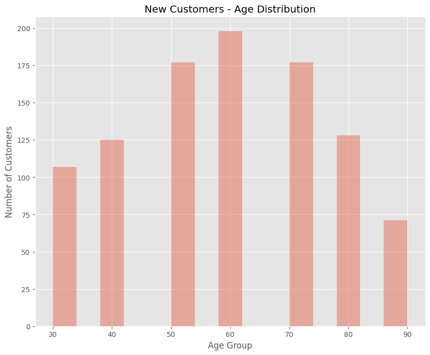

```python
plt.figure(figsize=(10,8))
sns.distplot(new_cust['age_group'], kde=False, bins=15)
plt.xlabel('Age Group')
plt.ylabel('Number of Customers')
plt.title('New Customers - Age Distribution')

plt.show()
```

**Here 20 is under 20, 30 is 20-29 age bracket**

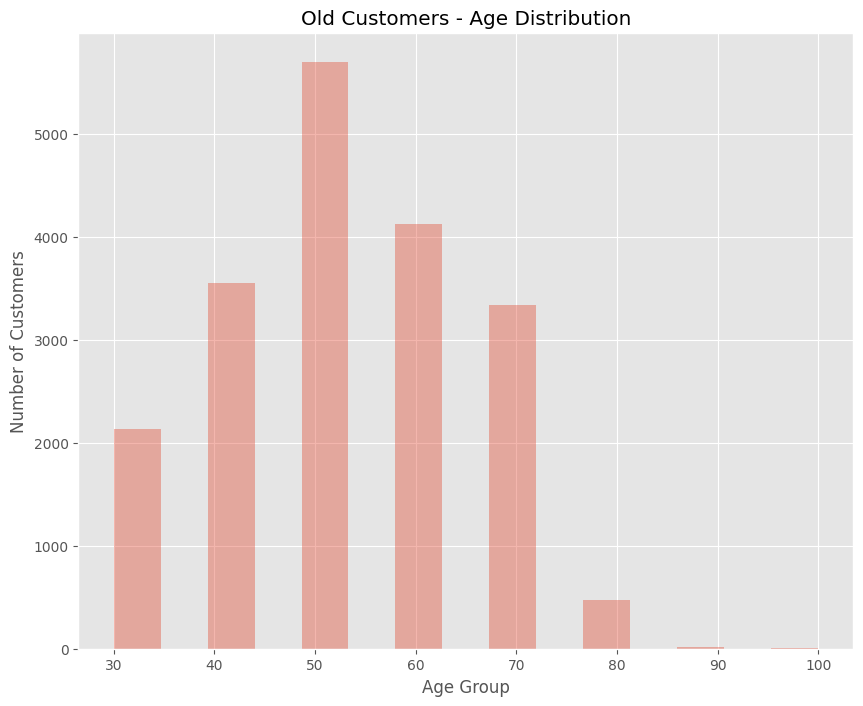

```python
plt.figure(figsize=(10,8))
sns.distplot(cust_trans_rfm['age_group'], kde=False, bins=15)
plt.xlabel('Age Group')
plt.ylabel('Number of Customers')
plt.title('Old Customers - Age Distribution')

plt.show()
```

**Here 20 is under 20, 30 is 20-29 age bracket**

Most new customers fall within the age groups 40–49, 50–59, and 60–69, with the highest concentration in the 50–59 age group. In contrast, the majority of old customers belong to the 40–49 and 50–59 age groups, with the 40–49 group having the largest share.

This indicates a shift in age demographics, where the 40–49 age group, previously dominant among old customers, has seen a decline in the new customer base. At the same time, there is a notable increase in customers aged 50–59 among the new customers compared to the old.

**Bike related purchases over last 3 years by gender (Old vs New Customer)**

```python
new_cust_pur_by_gender=new_cust.groupby("gender")["past_3_years_bike_related_purchases"].sum().reset_index()
new_cust_pur_by_gender
```

|  | gender | past_3_years_bike_related_purchases |
| --- | --- | --- |
| 0 | Female | 25212 |
| 1 | Male | 23765 |

```python
total_purchase=new_cust["past_3_years_bike_related_purchases"].sum()
total_purchase
```

```
48977
```

```python
new_cust_pur_by_gender["per_of_total"]=round((new_cust_pur_by_gender["past_3_years_bike_related_purchases"]/total_purchase)*100,2)
new_cust_pur_by_gender
```

|  | gender | past_3_years_bike_related_purchases | per_of_total |
| --- | --- | --- | --- |
| 0 | Female | 25212 | 51.48 |
| 1 | Male | 23765 | 48.52 |

```python
old_cust_pur_by_gender=cust_trans_rfm.groupby("gender")["past_3_years_bike_related_purchases"].sum().reset_index()
old_cust_pur_by_gender
```

|  | gender | past_3_years_bike_related_purchases |
| --- | --- | --- |
| 0 | Female | 478488 |
| 1 | Male | 468943 |

```python
total_purchase_old=cust_trans_rfm["past_3_years_bike_related_purchases"].sum()
total_purchase_old
```

```
947431
```

```python
old_cust_pur_by_gender["per_of_total"]=round((old_cust_pur_by_gender["past_3_years_bike_related_purchases"]/total_purchase_old)*100,2)

old_cust_pur_by_gender
```

|  | gender | past_3_years_bike_related_purchases | per_of_total |
| --- | --- | --- | --- |
| 0 | Female | 478488 | 50.5 |
| 1 | Male | 468943 | 49.5 |

Female customers have consistently contributed more to bike-related purchases in both old and new customer segments. In the new customer group, females make up 51.48% of purchases, while males account for 48.52%. This reflects a fairly balanced gender distribution, with a slight majority of female customers among recent acquisitions.

**Job Industry Customer Distribution**

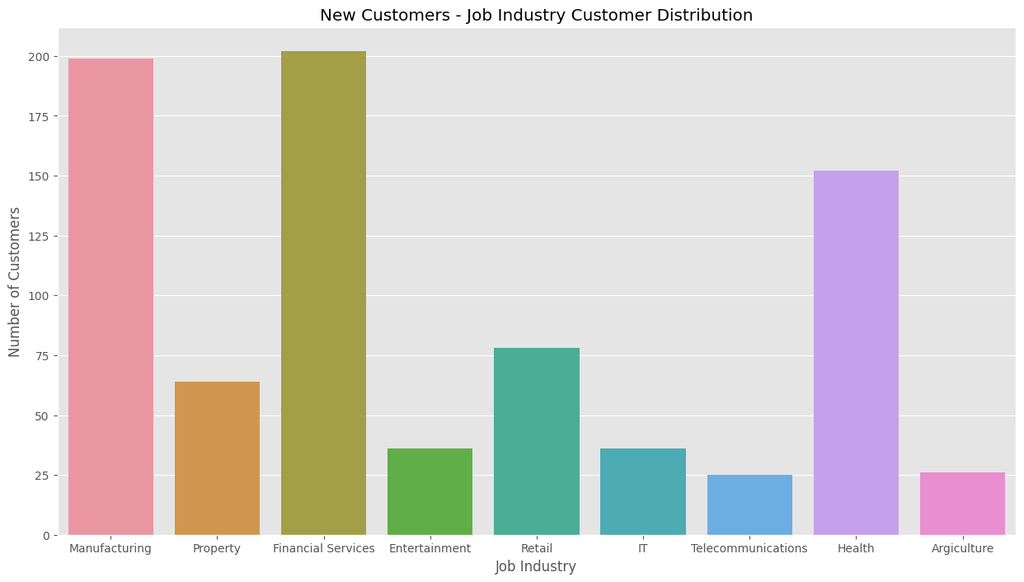

```python
plt.figure(figsize=(15,8))
sns.countplot(x='job_industry_category',data=new_cust[~(new_cust['job_industry_category']=='Missing')])
plt.xlabel('Job Industry')
plt.ylabel('Number of Customers')
plt.title('New Customers - Job Industry Customer Distribution')

plt.show()
```

Among new customers, the highest sales are generated from industries such as Finance, Manufacturing, and Health, while the lowest sales come from Agriculture and Telecommunications. A similar trend is observed among old customers as well, indicating consistent industry-wise performance across both segments

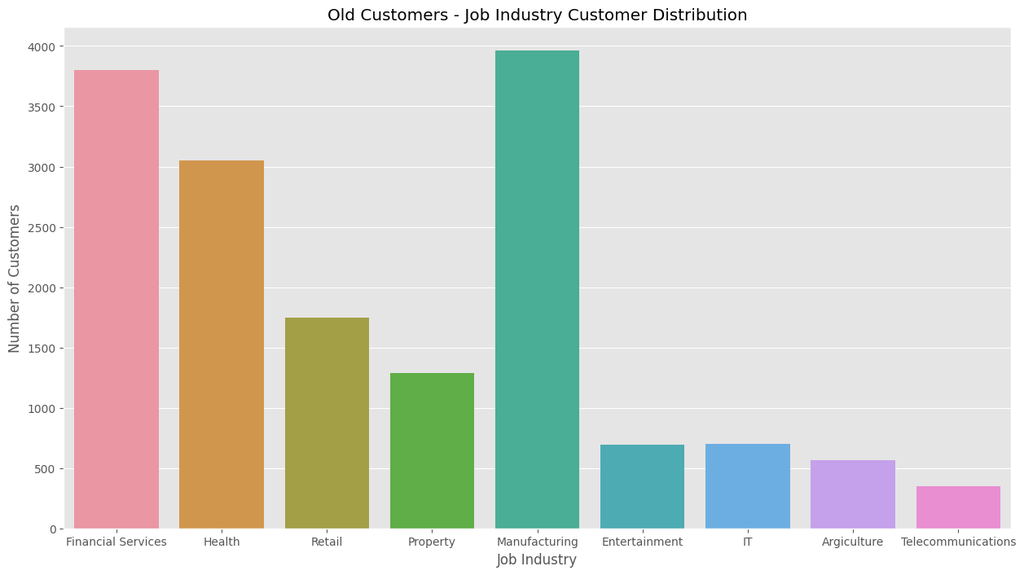

```python
plt.figure(figsize=(15,8))
sns.countplot(x='job_industry_category',data=cust_trans_rfm[~(cust_trans_rfm['job_industry_category']=='Missing')])
plt.xlabel('Job Industry')
plt.ylabel('Number of Customers')
plt.title('Old Customers - Job Industry Customer Distribution')

plt.show()
```

**Wealth Segmentation**

```python
#Based on wealth segment no of customer in old customer data
cust_trans_rfm.groupby("wealth_segment").size().reset_index(name="no_of_customers").sort_values(by="no_of_customers",ascending=False)
```

|  | wealth_segment | no_of_customers |
| --- | --- | --- |
| 2 | Mass Customer | 9703 |
| 1 | High Net Worth | 4931 |
| 0 | Affluent Customer | 4720 |

```python
#based on wealth segment no of customer in new customer data
new_cust.groupby("wealth_segment").size().reset_index(name="no_of_customers").sort_values(by="no_of_customers",ascending=False)
```

|  | wealth_segment | no_of_customers |
| --- | --- | --- |
| 2 | Mass Customer | 499 |
| 1 | High Net Worth | 249 |
| 0 | Affluent Customer | 235 |

In both Old and New customer list the highest number of customer are from the group of "mass customer"

```python
#Based on wealth segment and age group no of customer in old customer data

wealth_age_old=cust_trans_rfm.groupby(["age_group","wealth_segment"]).size().reset_index(name="no_of_customers").sort_values(by="no_of_customers",ascending=False)

wealth_age_old
```

|  | age_group | wealth_segment | no_of_customers |
| --- | --- | --- | --- |
| 8 | 50 | Mass Customer | 2908 |
| 11 | 60 | Mass Customer | 1999 |
| 14 | 70 | Mass Customer | 1732 |
| 5 | 40 | Mass Customer | 1702 |
| 7 | 50 | High Net Worth | 1418 |
| 6 | 50 | Affluent Customer | 1374 |
| 10 | 60 | High Net Worth | 1142 |
| 2 | 30 | Mass Customer | 1100 |
| 4 | 40 | High Net Worth | 984 |
| 9 | 60 | Affluent Customer | 983 |
| 3 | 40 | Affluent Customer | 871 |
| 12 | 70 | Affluent Customer | 804 |
| 13 | 70 | High Net Worth | 802 |
| 0 | 30 | Affluent Customer | 581 |
| 1 | 30 | High Net Worth | 450 |
| 17 | 80 | Mass Customer | 254 |
| 16 | 80 | High Net Worth | 128 |
| 15 | 80 | Affluent Customer | 92 |
| 21 | 100 | Affluent Customer | 10 |
| 20 | 90 | Mass Customer | 8 |
| 19 | 90 | High Net Worth | 7 |
| 18 | 90 | Affluent Customer | 5 |

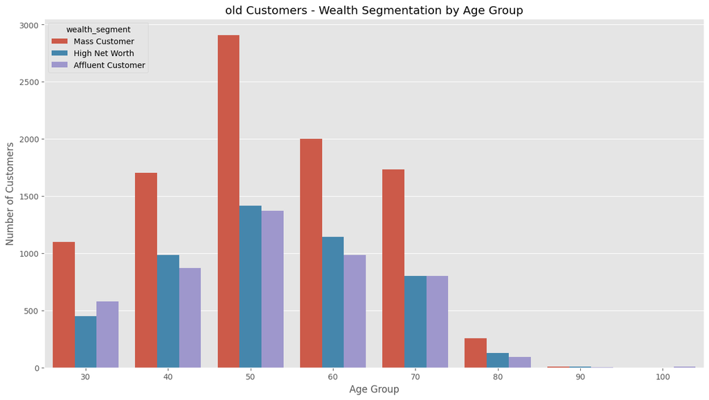

```python
plt.figure(figsize=(15,8))
sns.barplot(x='age_group', y='no_of_customers' , hue='wealth_segment', data=wealth_age_old)
plt.xlabel('Age Group')
plt.ylabel('Number of Customers')
plt.title('old Customers - Wealth Segmentation by Age Group')
plt.show()
```

```python
#based on wealth segmentand age group no of customer in new customer data
wealth_age_new=new_cust.groupby(["age_group","wealth_segment"]).size().reset_index(name="no_of_customers").sort_values(by="no_of_customers",ascending=False)
wealth_age_new
```

|  | age_group | wealth_segment | no_of_customers |
| --- | --- | --- | --- |
| 11 | 60 | Mass Customer | 113 |
| 14 | 70 | Mass Customer | 91 |
| 8 | 50 | Mass Customer | 83 |
| 5 | 40 | Mass Customer | 62 |
| 17 | 80 | Mass Customer | 61 |
| 13 | 70 | High Net Worth | 51 |
| 2 | 30 | Mass Customer | 51 |
| 9 | 60 | Affluent Customer | 48 |
| 6 | 50 | Affluent Customer | 47 |
| 7 | 50 | High Net Worth | 47 |
| 4 | 40 | High Net Worth | 40 |
| 20 | 90 | Mass Customer | 38 |
| 10 | 60 | High Net Worth | 37 |
| 12 | 70 | Affluent Customer | 35 |
| 16 | 80 | High Net Worth | 35 |
| 0 | 30 | Affluent Customer | 35 |
| 15 | 80 | Affluent Customer | 32 |
| 3 | 40 | Affluent Customer | 23 |
| 1 | 30 | High Net Worth | 21 |
| 19 | 90 | High Net Worth | 18 |
| 18 | 90 | Affluent Customer | 15 |

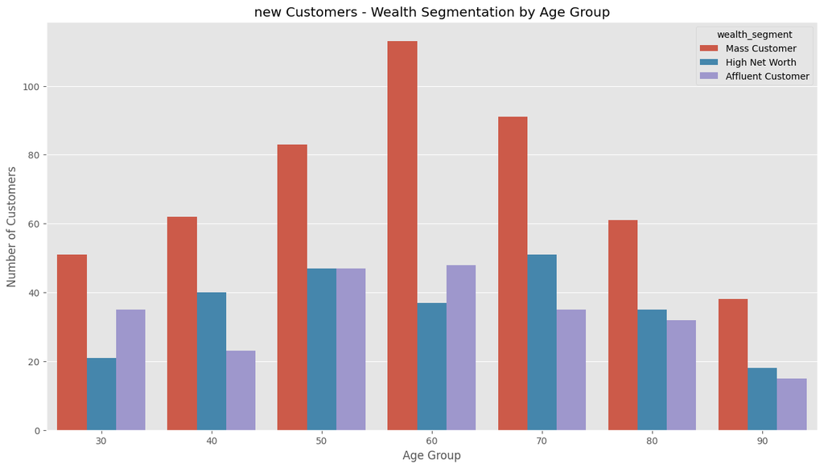

```python
plt.figure(figsize=(15,8))
sns.barplot(x='age_group', y='no_of_customers' , hue='wealth_segment', data=wealth_age_new)
plt.xlabel('Age Group')
plt.ylabel('Number of Customers')
plt.title('new Customers - Wealth Segmentation by Age Group')
plt.show()
```

In the new customer list, the Mass Customer group again dominates across age groups. The High Net Worth segment holds the second position in most cases, except for the 20–29 and 50–59 age groups, where the Affluent group has a higher customer count than High Net Worth individuals.

**RFM analysis -Scatter Plot**

**Recency vs Monetary**

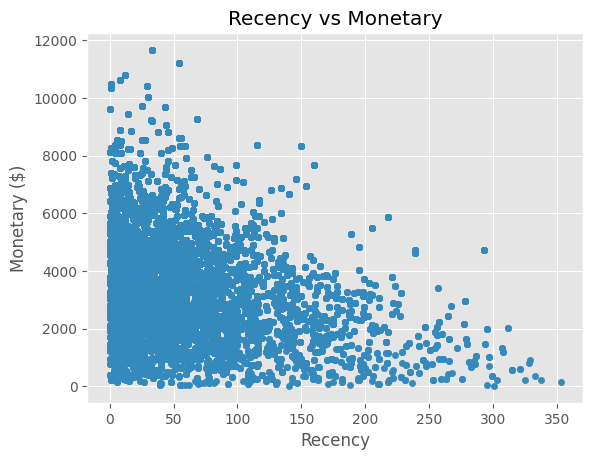

```python
plt.figure(figsize=(8,7))
cust_trans_rfm.plot.scatter(x='recency' , y='monetary')
plt.xlabel('Recency')
plt.ylabel('Monetary ($)')
plt.title('Recency vs Monetary')
plt.show()
```

The visualization shows that customers with more recent purchase activity tend to generate higher revenue compared to those who made purchases a long time ago.Customer who purchased between (50 to 150) days generated moderate revenue where else the customer who visited 250 days ago generated low revenue

**Frequency vs Monetary**

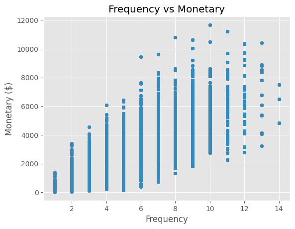

```python
plt.figure(figsize=(8,7))
cust_trans_rfm.plot.scatter(x='frequency' , y='monetary')
plt.xlabel('Frequency')
plt.ylabel('Monetary ($)')
plt.title('Frequency vs Monetary')
plt.show()
```

The visualization indicates that a higher number of purchases (frequency) is associated with greater revenue generation. There is a positive correlation between purchase frequency and profit, suggesting that customers who buy more frequently contribute more to overall revenue.

**Customer Segmentation**

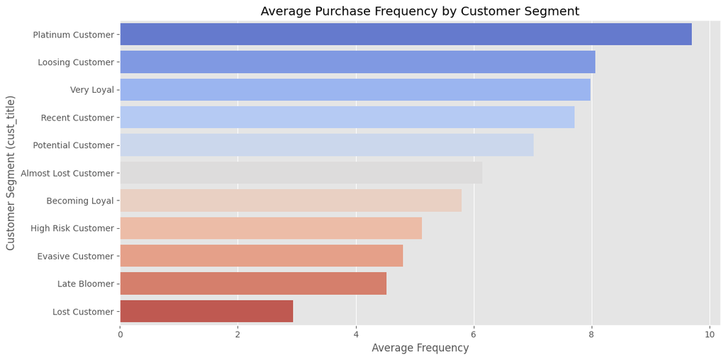

```python
# Grouping by cust_title and calculating average frequency
title_freq = cust_trans_rfm.groupby('cust_title')['frequency'].mean().reset_index()

# Sorting for better visualization
title_freq = title_freq.sort_values(by='frequency', ascending=False)

# Plotting the bar chart
plt.figure(figsize=(12,6))
sns.barplot(data=title_freq, x='frequency', y='cust_title', palette='coolwarm')
plt.title('Average Purchase Frequency by Customer Segment')
plt.xlabel('Average Frequency')
plt.ylabel('Customer Segment (cust_title)')
plt.tight_layout()
plt.show()
```

The analysis of average purchase frequency by customer segment reveals that Platinum Customers, Losing Customers, Very Loyal Customers, Recent Customers, and Potential Customers exhibit higher purchase frequencies. These segments are crucial, as customers who purchase more frequently often contribute significantly to overall revenue.

Interestingly, Losing Customers stand out with a high purchase frequency, suggesting that although their recent engagement may be declining, they have been valuable in the past. This presents an opportunity for the company to re-engage and retain this group through targeted marketing, personalized offers, or loyalty programs.

Focusing on these high-frequency segments — especially those at risk of churn like Losing Customers — can help the company maximize revenue, boost retention, and enhance long-term customer value

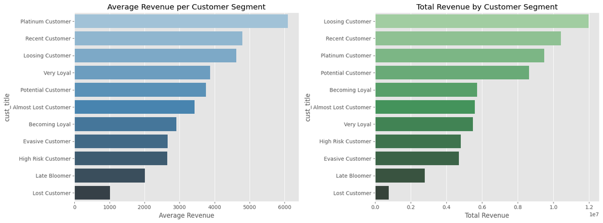

```python
fig, axes = plt.subplots(1, 2, figsize=(16, 6))

# Average revenue
avg_rev = cust_trans_rfm.groupby('cust_title')['monetary'].mean().sort_values(ascending=False)
sns.barplot(x=avg_rev.values, y=avg_rev.index, ax=axes[0], palette='Blues_d')
axes[0].set_title('Average Revenue per Customer Segment')
axes[0].set_xlabel('Average Revenue')

# Total revenue
total_rev = cust_trans_rfm.groupby('cust_title')['monetary'].sum().sort_values(ascending=False)
sns.barplot(x=total_rev.values, y=total_rev.index, ax=axes[1], palette='Greens_d')
axes[1].set_title('Total Revenue by Customer Segment')
axes[1].set_xlabel('Total Revenue')

plt.tight_layout()
plt.show()
```

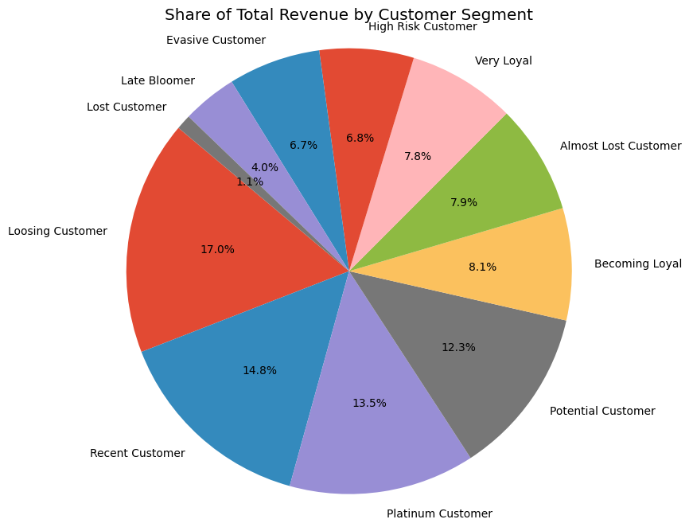

```python
# Summing monetary values by customer segment
segment_monetary_sum = cust_trans_rfm.groupby('cust_title')['monetary'].sum().sort_values(ascending=False)

# Plot
plt.figure(figsize=(10,8))
plt.pie(segment_monetary_sum, labels=segment_monetary_sum.index, autopct='%1.1f%%', startangle=140)
plt.title('Share of Total Revenue by Customer Segment')
plt.axis('equal')
plt.show()
```

**Insights from Average Revenue by Customer Segment:**

The analysis of average revenue across customer segments shows that Platinum, Recent, Very Loyal, and Potential Customers are top contributors, as expected due to their consistent purchasing behavior. However, a noteworthy insight is that Losing Customers generate a higher share of revenue than even the Platinum segment.

This indicates that while these customers have contributed significantly in the past, they are at risk of churn — making them a critical group to prioritize. Failing to re-engage them could result in a substantial loss of future revenue.

In addition, the Almost Lost segment, though currently less active, shows signs of valuable past behavior. With the right retention strategies — such as targeted promotions, personalized communication, or loyalty incentives — these customers could be brought back into high-value segments.

```python
# Calculating the number of unique customers under a customer title.

cust_per_title = cust_trans_rfm[['cust_title', 'customer_id','rank']].drop_duplicates().groupby(
    ['cust_title','rank']).size().reset_index(name="no_of_customers").sort_values('no_of_customers',ascending=False)
cust_per_title
```

|  | cust_title | rank | no_of_customers |
| --- | --- | --- | --- |
| 2 | Evasive Customer | 10 | 388 |
| 3 | High Risk Customer | 8 | 371 |
| 9 | Recent Customer | 4 | 357 |
| 1 | Becoming Loyal | 3 | 344 |
| 8 | Potential Customer | 5 | 340 |
| 5 | Loosing Customer | 7 | 333 |
| 4 | Late Bloomer | 6 | 332 |
| 0 | Almost Lost Customer | 9 | 315 |
| 6 | Lost Customer | 11 | 291 |
| 10 | Very Loyal | 2 | 181 |
| 7 | Platinum Customer | 1 | 164 |

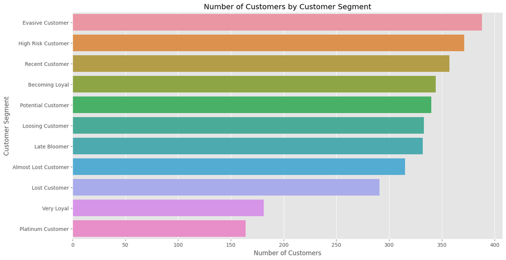

```python
# Plotting the Number of Customers

plt.figure(figsize=(15,8))
sns.barplot(y='cust_title' , x='no_of_customers', data=cust_per_title)
plt.xlabel('Number of Customers')
plt.ylabel('Customer Segment')
plt.title('Number of Customers by Customer Segment')
plt.show()
```

The above visualization describe

1. "Evasive Customer" and "High Risk" Customer segments have the highest number of customers, indicating many customers are at risk of disengagement or loss.
2. Segments like "Platinum Customer" and "Very Loyal" have the fewest customers, suggesting a smaller but highly valuable group that purchases frequently and recently.
3. The majority of customers fall into mid-risk or developing loyalty categories such as "Recent", "Becoming Loyal", and "Potential Customers", which presents opportunities for targeted marketing and retention strategies.

This distribution highlights the need for efforts to retain high-risk customers and nurture potential and recent buyers into more loyal segments.